# FinalP2

```r
# 2. Extract Posterior Samples for sigma
bayes_total_matrix <- as.matrix(bayes_interaction)
# Extract the column named "sigma" (the residual standard error)
sigma_samples <- bayes_total_matrix[,"sigma"]

# Check basic summary statistics of sigma posterior.
sigma_post_summary <- summary(sigma_samples)
print(sigma_post_summary)
```

```
##    Min. 1st Qu.  Median    Mean 3rd Qu.    Max.
## 0.05230 0.05689 0.05784 0.05786 0.05882 0.06334
```

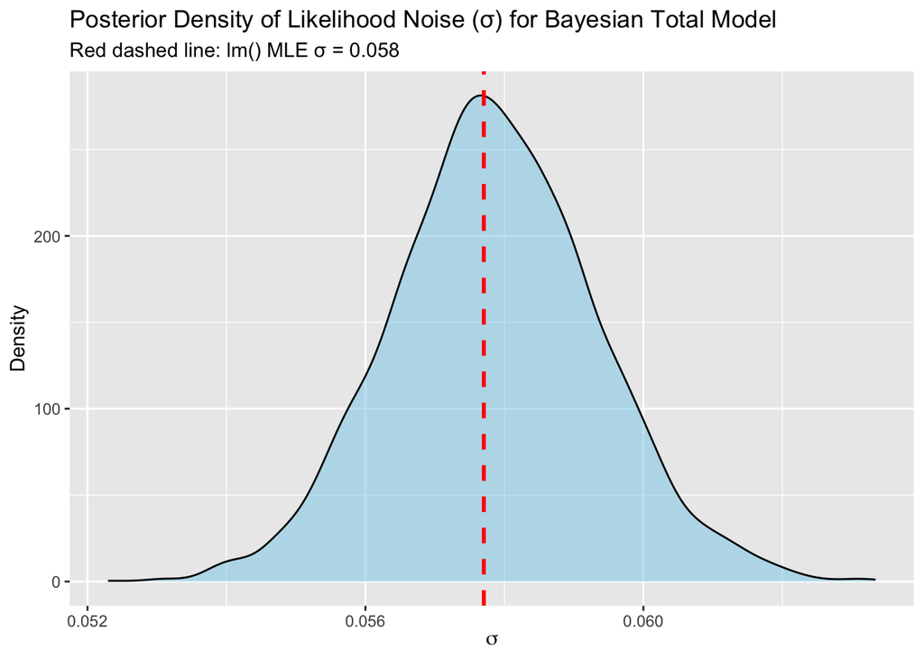

```r
# 3. Create a Density Plot for the Posterior Distribution of sigma
df_sigma <- data.frame(sigma = sigma_samples)

ggplot(df_sigma, aes(x = sigma)) +
  geom_density(fill = "skyblue", alpha = 0.5) +
  geom_vline(xintercept = sigma_mle, color = "red", linetype = "dashed", size = 1) +
  labs(title = "Posterior Density of Likelihood Noise (σ) for Bayesian Total Model",
       subtitle = paste("Red dashed line: lm() MLE σ =", round(sigma_mle, 3)),
       x = expression(sigma),
       y = "Density")
```

The lm maximum likelihood estimate looks to be at or very close to correspond to the highest density point on the uncertainty plot of sigma.

I think we have a reasonable certainty of the value of sigma. The large majority of the density plot ranges between the values .054 and .062, which nicely aligns with the MLE estimate and is not a very large range of possible values.

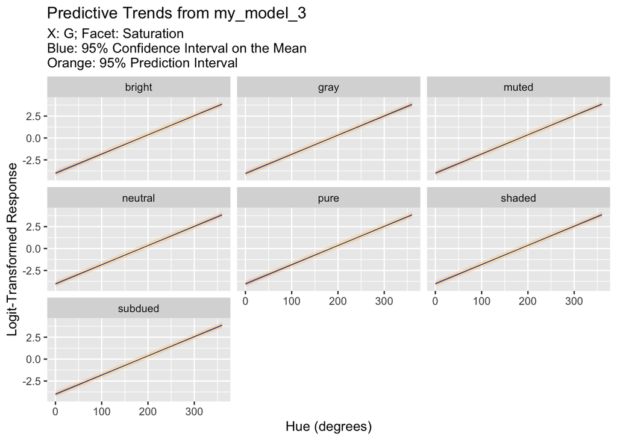

```r
mean_G <- mean(dfii$G, na.rm = TRUE)
mean_B <- mean(dfii$B, na.rm = TRUE)
mean_Hue <- mean(dfii$Hue, na.rm = TRUE)

# Create a grid of Hue and Saturation values.
newdata_my3 <- expand.grid(G = seq(0, 360, length.out = 100),
                           Saturation = sort(unique(dfii$Saturation)))
newdata_my3 <- newdata_my3 %>%
  mutate(
         Hue = mean_Hue,
         B = mean_B)

# Get the mean prediction and intervals from my_model_3
pred_conf_my3 <- predict(my_model_3, newdata = newdata_my3, interval = "confidence")
pred_pred_my3 <- predict(my_model_3, newdata = newdata_my3, interval = "prediction")

# Combine the predictions with newdata_my3
newdata_my3 <- newdata_my3 %>%
  mutate(fit_conf = pred_conf_my3[,"fit"],
         lwr_conf = pred_conf_my3[,"lwr"],
         upr_conf = pred_conf_my3[,"upr"],
         fit_pred = pred_pred_my3[,"fit"],
         lwr_pred = pred_pred_my3[,"lwr"],
         upr_pred = pred_pred_my3[,"upr"])

#-------------
# Prepare newdata for interaction_model
#-------------
# For interaction_model, predictors include: R, G, B, Hue, and the factors Lightness and Saturation.
# We choose Hue as primary (varied 0 to 360) and use Lightness for faceting.
# We fix R, G, and B at their means and set Saturation to a reference level.
mean_R <- mean(dfii$R, na.rm = TRUE)
mean_G <- mean(dfii$G, na.rm = TRUE)
mean_B <- mean(dfii$B, na.rm = TRUE)
mean_Hue <- mean(dfii$Hue, na.rm = TRUE)
# Choose a reference level for Saturation (here, the first level)
ref_Saturation <- sort(unique(dfii$Saturation))[1]

newdata_inter <- expand.grid(G = seq(0, 360, length.out = 100),
                             Lightness = sort(unique(dfii$Lightness)))
newdata_inter <- newdata_inter %>%
  mutate(R = mean_R,
         Hue = mean_Hue,
         B = mean_B,
         Saturation = ref_Saturation)

# Get predictions from interaction_model
pred_conf_inter <- predict(interaction_model, newdata = newdata_inter, interval = "confidence")
pred_pred_inter <- predict(interaction_model, newdata = newdata_inter, interval = "prediction")

newdata_inter <- newdata_inter %>%
  mutate(fit_conf = pred_conf_inter[,"fit"],
         lwr_conf = pred_conf_inter[,"lwr"],
         upr_conf = pred_conf_inter[,"upr"],
         fit_pred = pred_pred_inter[,"fit"],
         lwr_pred = pred_pred_inter[,"lwr"],
         upr_pred = pred_pred_inter[,"upr"])

#-------------
# Plot Predictions for my_model_3
#-------------
p_my3 <- ggplot(newdata_my3, aes(x = G, y = fit_conf)) +
  # Confidence interval ribbon
  geom_ribbon(aes(ymin = lwr_conf, ymax = upr_conf), fill = "blue", alpha = 0.3) +
  # Prediction interval ribbon (wider)
  geom_ribbon(aes(ymin = lwr_pred, ymax = upr_pred), fill = "orange", alpha = 0.2) +
  geom_line(color = "black", size = .2) +
  facet_wrap(~ Saturation) +
  labs(title = "Predictive Trends from my_model_3",
       subtitle = "X: G; Facet: Saturation\nBlue: 95% Confidence Interval on the Mean\nOrange: 95% Prediction Interval",
       x = "Hue (degrees)",
       y = "Logit-Transformed Response")

#-------------
# Plot Predictions for interaction_model
#-------------
p_inter <- ggplot(newdata_inter, aes(x = G, y = fit_conf)) +
  geom_ribbon(aes(ymin = lwr_conf, ymax = upr_conf), fill = "blue", alpha = 0.3) +
  geom_ribbon(aes(ymin = lwr_pred, ymax = upr_pred), fill = "orange", alpha = 0.2) +
  geom_line(color = "black", size = .2) +
  facet_wrap(~ Lightness) +
  labs(title = "Predictive Trends from interaction_model",
       subtitle = "X: G; Facet: Lightness (with Saturation fixed at bright)", ref_Saturation, "')\nBlue: 95% Confidence Interval on the Mean\nOrange: 95% Prediction Interval",
       x = "Hue (degrees)",
       y = "Logit-Transformed Response")


print(p_my3)
```

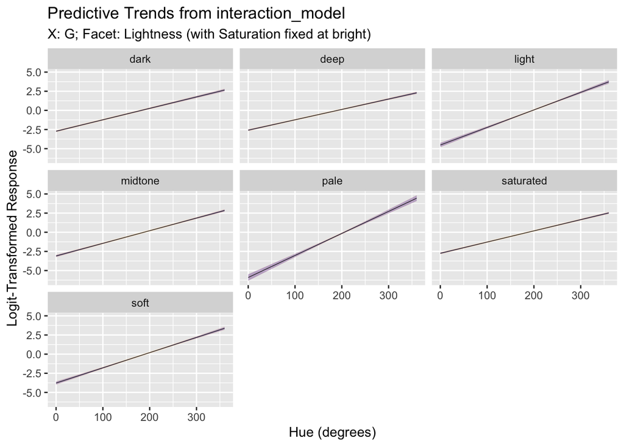

```r
print(p_inter)
```

The predictive trends between the two models are capturing the same thing. Despite trying to account for a cyclical relationship between saturation and Hue in my_model_3, the strongest relationship still remained the linear regression with G and logit response (stratified by saturation). Similarly but not exactly the same, the interaction model exhibited an extremely strong relationship between G and logit response when stratified by Lightness. Hue and Saturation did exhibit some interesting sin behavior, but the fit was not strong enough to justify it being a primary feature.

```r
ctrl   <- trainControl(method = "cv", number = 5,
                       summaryFunction = defaultSummary)  # gives RMSE, Rsquared, MAE
metric <- "RMSE"

# helper to wrap train() with consistent args
train_model <- function(form, method, tuneLength=5) {
  train(form, data      = dfii,
             method    = method,
             metric    = metric,
             trControl = ctrl,
             preProcess= c("center","scale"),
             tuneLength= tuneLength,
              savePredictions = "final")
}

# 1) Linear additive
lin_add    <- train_model(y ~ R + G + B + Hue + Lightness + Saturation, "lm")
# 2) Pairwise continuous interactions + categorical
lin_pair   <- train_model(y ~ (R + G + B + Hue)^2 + Lightness + Saturation, "lm")
# 3) Full interaction model
lin_inter  <- train_model(y ~ (R + G + B + Hue)*(Lightness + Saturation), "lm")
# 4) Elastic net on pairwise
en_pair    <- train_model(y ~ (R + G + B + Hue)^2 + Lightness + Saturation, "glmnet", tuneLength=10)

# 5) Elastic net on full interaction
en_inter   <- train_model(y ~ (R + G + B + Hue)*(Lightness + Saturation), "glmnet", tuneLength=10)

# 6) Neural net
nn_mod     <- train_model(y ~ R + G + B + Hue + Lightness + Saturation, "nnet", tuneLength=10)
# 7) Random forest
rf_mod     <- train_model(y ~ R + G + B + Hue + Lightness + Saturation, "rf", tuneLength=5)

# 8) Gradient boosting
gbm_mod    <- train_model(y ~ R + G + B + Hue + Lightness + Saturation, "xgbTree", tuneLength=5)
```

[output not shown]

[output cut: 3447 more lines]

[output not shown]

```r
# 9) Two extras: SVM radial & k‑NN
svm_mod    <- train_model(y ~ R + G + B + Hue + Lightness + Saturation, "svmRadial", tuneLength=5)
knn_mod    <- train_model(y ~ R + G + B + Hue + Lightness + Saturation, "kknn",    tuneLength=5)

# collect results
models <- list(
  Linear_Add       = lin_add,
  Pairwise_Add     = lin_pair,
  Interaction      = lin_inter,
  ElasticNet_Pair  = en_pair,
  ElasticNet_Inter = en_inter,
  Neural_Net       = nn_mod,
  Random_Forest    = rf_mod,
  GBM              = gbm_mod,
  SVM_Radial       = svm_mod,
  kNN              = knn_mod
)

res <- resamples(models)

# Show RMSE & Rsquared
summary(res, metric = c("RMSE","Rsquared"))
```

```
##
## Call:
## summary.resamples(object = res, metric = c("RMSE", "Rsquared"))
##
## Models: Linear_Add, Pairwise_Add, Interaction, ElasticNet_Pair, ElasticNet_Inter, Neural_Net, Random_Forest, GBM, SVM_Radial, kNN
## Number of resamples: 5
##
## RMSE
##                        Min.    1st Qu.     Median       Mean    3rd Qu.
## Linear_Add       0.08178830 0.08789214 0.08918791 0.08940916 0.09353771
## Pairwise_Add     0.07314401 0.07867437 0.08118795 0.08075829 0.08272338
## Interaction      0.05783849 0.05907904 0.06508885 0.06299308 0.06544910
## ElasticNet_Pair  0.07773697 0.08035569 0.08122054 0.08072018 0.08169467
## ElasticNet_Inter 0.06657147 0.06969356 0.07098023 0.07242928 0.07454842
## Neural_Net       0.92887373 0.94181459 0.95794144 0.96692072 0.99791710
## Random_Forest    0.07022031 0.07028898 0.07031915 0.07202644 0.07346906
## GBM              0.05329170 0.05692911 0.06272573 0.06228311 0.06303992
## SVM_Radial       0.08342255 0.09197379 0.09263977 0.09196987 0.09490734
## kNN              0.20542823 0.21881762 0.21891738 0.22021508 0.22369859
##                        Max. NA's
## Linear_Add       0.09463974    0
## Pairwise_Add     0.08806174    0
## Interaction      0.06750991    0
## ElasticNet_Pair  0.08259304    0
## ElasticNet_Inter 0.08035271    0
## Neural_Net       1.00805674    0
## Random_Forest    0.07583472    0
## GBM              0.07542906    0
## SVM_Radial       0.09690591    0
## kNN              0.23421358    0
##
## Rsquared
##                       Min.   1st Qu.    Median      Mean   3rd Qu.      Max.
## Linear_Add       0.9937242 0.9939851 0.9945351 0.9943287 0.9946196 0.9947793
## Pairwise_Add     0.9943482 0.9950934 0.9954110 0.9953554 0.9955994 0.9963251
## Interaction      0.9968079 0.9969718 0.9970458 0.9971916 0.9973520 0.9977802
## ElasticNet_Pair  0.9947933 0.9949847 0.9954610 0.9953428 0.9955667 0.9959083
## ElasticNet_Inter 0.9952616 0.9963271 0.9963522 0.9962696 0.9966332 0.9967737
## Neural_Net       0.7277682 0.7420265 0.7428983 0.7436879 0.7497724 0.7559741
## Random_Forest    0.9960379 0.9960597 0.9965508 0.9964111 0.9966334 0.9967736
## GBM              0.9960031 0.9971890 0.9975726 0.9972818 0.9977031 0.9979410
## SVM_Radial       0.9935516 0.9940035 0.9940682 0.9942848 0.9942990 0.9955018
## kNN              0.9626731 0.9628782 0.9661668 0.9657639 0.9682264 0.9688752
##                  NA's
## Linear_Add          0
## Pairwise_Add        0
## Interaction         0
## ElasticNet_Pair     0
## ElasticNet_Inter    0
## Neural_Net          0
## Random_Forest       0
## GBM                 0
## SVM_Radial          0
## kNN                 0
```

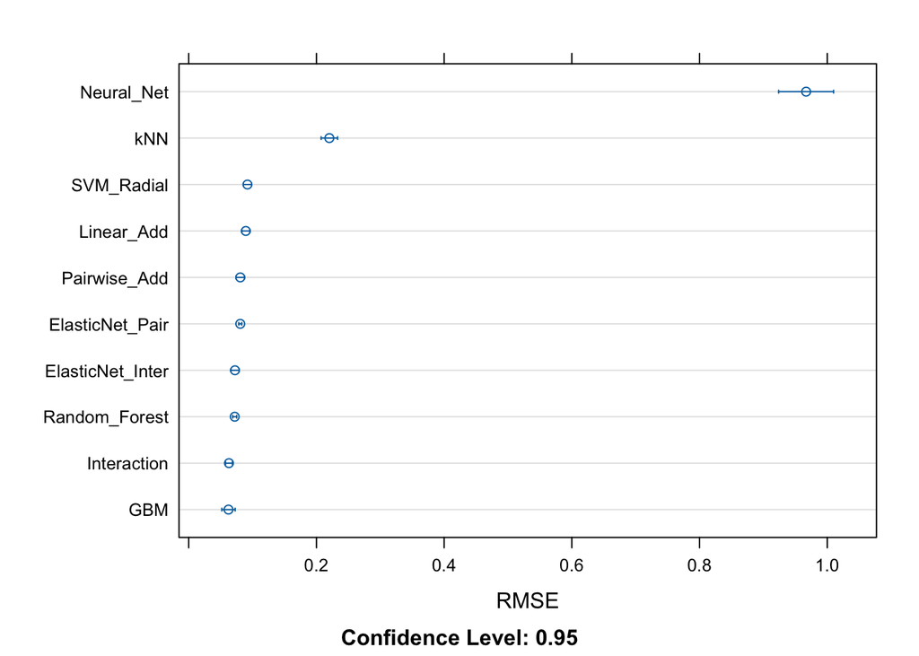

```r
dotplot(res, metric = metric)
```

SAVING THE MODEL FOR USE IN PART 4

```r
ctrl <- trainControl(
  method = "cv",
  number = 5,
  summaryFunction = defaultSummary,
  savePredictions = "final"
)

lin_add <- train_model(y ~ R + G + B + Hue + Lightness + Saturation,
  method = "lm")
str(lin_add$pred)
```

```
## 'data.frame':    835 obs. of  5 variables:
##  $ intercept: logi  TRUE TRUE TRUE TRUE TRUE TRUE ...
##  $ pred     : num  -1.05 -2.33 -2.21 -1.91 -2.23 ...
##  $ obs      : num  -1.1 -2.31 -2.2 -1.9 -2.2 ...
##  $ rowIndex : int  10 24 28 35 42 49 52 53 65 70 ...
##  $ Resample : chr  "Fold1" "Fold1" "Fold1" "Fold1" ...
```

```r
lin_add %>% readr::write_rds("lin_add.rds")
```

```r
lin_add = readr::read_rds("lin_add.rds")

glimpse(lin_add)
```

[output not shown]

[output cut: 195 more lines]

[output not shown]